# Shooting Project RMD

Libraries imported: tidyverse, ggplot2, nnet

## Initial Data Import

The first step in the project in the analysis is to import the NYPD Shooting Incident Data. This dataset describes every recorded shooting incident from 2006 to 2024 in New York City and includes data relating to the relevant location, time, victim attributes, and perpetrator attributes. In order to import the data, we copy the link address to get the URL, and read the csv accordingly.

```r
url_in <- "https://data.cityofnewyork.us/api/v3/views/833y-fsy8/export.csv?accessType=DOWNLOAD"
nypd_data <- read_csv(url_in, show_col_types = FALSE)
nypd_data
```

```
## # A tibble: 29,744 × 21
##    INCIDENT_KEY OCCUR_DATE OCCUR_TIME BORO      LOC_OF_OCCUR_DESC PRECINCT
##           <dbl> <chr>      <time>     <chr>     <chr>                <dbl>
##  1    298699604 12/31/2024 19:16      BROOKLYN  OUTSIDE                 69
##  2    298699604 12/31/2024 19:16      BROOKLYN  OUTSIDE                 69
##  3    298672096 12/30/2024 16:45      BRONX     OUTSIDE                 47
##  4    298672094 12/30/2024 12:15      BRONX     OUTSIDE                 52
##  5    298672095 12/30/2024 20:32      BRONX     INSIDE                  41
##  6    298672096 12/30/2024 16:45      BRONX     OUTSIDE                 47
##  7    298672097 12/30/2024 18:48      BROOKLYN  OUTSIDE                 60
##  8    298672096 12/30/2024 16:45      BRONX     OUTSIDE                 47
##  9    298628071 12/29/2024 17:24      MANHATTAN OUTSIDE                 23
## 10    298628070 12/29/2024 16:21      BRONX     OUTSIDE                 43
## # ℹ 29,734 more rows
## # ℹ 15 more variables: JURISDICTION_CODE <dbl>, LOC_CLASSFCTN_DESC <chr>,
## #   LOCATION_DESC <chr>, STATISTICAL_MURDER_FLAG <lgl>, PERP_AGE_GROUP <chr>,
## #   PERP_SEX <chr>, PERP_RACE <chr>, VIC_AGE_GROUP <chr>, VIC_SEX <chr>,
## #   VIC_RACE <chr>, X_COORD_CD <dbl>, Y_COORD_CD <dbl>, Latitude <dbl>,
## #   Longitude <dbl>, Lon_Lat <chr>
```

## Data Transformations

The first step I took in tidying up the data was to look at which datatypes needed to be transformed to be better suited for analysis. The `OCCUR_DATE` column, for example, is a column of datatype `<chr>`, so I cast it to `<date>`. Several columns were the datatype `<dbl>` (`PRECINCT`, `JURISDICTION_CODE`, etc.) though they were not actually numeric columns, so I converted them into factors. I ended up determining that those columns were not necessarily additive, so I did not include them in the final selection of columns. I left a line factorizing the `JURISDICTION_CODE` in the code as an example of how the factorization would occur. The result of these transformations are below:

```r
nypd <- nypd_data %>%
  mutate(DATE = mdy(OCCUR_DATE),
         JURISDICTION_CODE = as.factor(JURISDICTION_CODE)) %>%
  rename(LOCATION = 'LOC_CLASSFCTN_DESC') %>%
  select(DATE, BORO, PERP_AGE_GROUP, PERP_SEX, PERP_RACE,
         VIC_AGE_GROUP, VIC_SEX, VIC_RACE)
nypd
```

```
## # A tibble: 29,744 × 8
##    DATE       BORO      PERP_AGE_GROUP PERP_SEX PERP_RACE VIC_AGE_GROUP VIC_SEX
##    <date>     <chr>     <chr>          <chr>    <chr>     <chr>         <chr>
##  1 2024-12-31 BROOKLYN  25-44          M        BLACK     25-44         M
##  2 2024-12-31 BROOKLYN  25-44          M        BLACK     18-24         M
##  3 2024-12-30 BRONX     (null)         (null)   (null)    <18           F
##  4 2024-12-30 BRONX     45-64          M        BLACK     25-44         M
##  5 2024-12-30 BRONX     18-24          M        BLACK     25-44         M
##  6 2024-12-30 BRONX     (null)         (null)   (null)    25-44         F
##  7 2024-12-30 BROOKLYN  25-44          M        BLACK     45-64         M
##  8 2024-12-30 BRONX     (null)         (null)   (null)    18-24         M
##  9 2024-12-29 MANHATTAN (null)         (null)   (null)    25-44         M
## 10 2024-12-29 BRONX     18-24          M        BLACK     <18           M
## # ℹ 29,734 more rows
## # ℹ 1 more variable: VIC_RACE <chr>
```

```r
summary(nypd)
```

```
##       DATE                   BORO         PERP_AGE_GROUP       PERP_SEX
##  Min.   :2006-01-01   Length   :29744   Length   :29744   Length   :29744
##  1st Qu.:2009-10-29   N.unique :    5   N.unique :   12   N.unique :    4
##  Median :2014-03-25   N.blank  :    0   N.blank  :    0   N.blank  :    0
##  Mean   :2014-10-31   Min.nchar:    5   Min.nchar:    3   Min.nchar:    1
##  3rd Qu.:2020-06-29   Max.nchar:   13   Max.nchar:    7   Max.nchar:    6
##  Max.   :2024-12-31                     NAs      : 9344   NAs      : 9310
##      PERP_RACE       VIC_AGE_GROUP        VIC_SEX           VIC_RACE
##  Length   :29744   Length   :29744   Length   :29744   Length   :29744
##  N.unique :    8   N.unique :    7   N.unique :    3   N.unique :    7
##  N.blank  :    0   N.blank  :    0   N.blank  :    0   N.blank  :    0
##  Min.nchar:    5   Min.nchar:    3   Min.nchar:    1   Min.nchar:    5
##  Max.nchar:   30   Max.nchar:    7   Max.nchar:    1   Max.nchar:   30
##  NAs      : 9310
```

## Data Cleaning

Of the selected columns, there are `(null)` values, which are being parsed as strings rather than nulls. This can be seen in the summary, in which despite these nulls existing, the minimum character counts are not 0. To remove these rows with null values, I filtered for rows that do not contain `(null)` in any `<chr>` column and nulls in any other column. Also, in the `PERP_AGE_GROUP` and `VIC_AGE_GROUP` columns, some age groups were formatted incorrectly. Due to the limited number of occurrences, I omitted these rows. The final transformed and cleaned table is below:

```r
nypd <- nypd %>%
  filter(if_all(everything(), ~ !is.na(.)),
         if_all(where(is.character), ~ . != "(null)"),
         if_all(all_of(c("VIC_AGE_GROUP", "PERP_AGE_GROUP")), ~ grepl("[<+-]", .x))
  )
nypd
```

```
## # A tibble: 15,557 × 8
##    DATE       BORO      PERP_AGE_GROUP PERP_SEX PERP_RACE  VIC_AGE_GROUP VIC_SEX
##    <date>     <chr>     <chr>          <chr>    <chr>      <chr>         <chr>
##  1 2024-12-31 BROOKLYN  25-44          M        BLACK      25-44         M
##  2 2024-12-31 BROOKLYN  25-44          M        BLACK      18-24         M
##  3 2024-12-30 BRONX     45-64          M        BLACK      25-44         M
##  4 2024-12-30 BRONX     18-24          M        BLACK      25-44         M
##  5 2024-12-30 BROOKLYN  25-44          M        BLACK      45-64         M
##  6 2024-12-29 BRONX     18-24          M        BLACK      <18           M
##  7 2024-12-28 MANHATTAN 25-44          M        BLACK      25-44         M
##  8 2024-12-28 MANHATTAN 18-24          F        BLACK      25-44         M
##  9 2024-12-27 BRONX     <18            M        BLACK HIS… 25-44         M
## 10 2024-12-27 BRONX     <18            M        BLACK HIS… 25-44         M
## # ℹ 15,547 more rows
## # ℹ 1 more variable: VIC_RACE <chr>
```

```r
summary(nypd)
```

```
##       DATE                   BORO         PERP_AGE_GROUP       PERP_SEX
##  Min.   :2006-01-01   Length   :15557   Length   :15557   Length   :15557
##  1st Qu.:2009-08-31   N.unique :    5   N.unique :    5   N.unique :    3
##  Median :2014-07-06   N.blank  :    0   N.blank  :    0   N.blank  :    0
##  Mean   :2014-12-14   Min.nchar:    5   Min.nchar:    3   Min.nchar:    1
##  3rd Qu.:2020-07-26   Max.nchar:   13   Max.nchar:    5   Max.nchar:    1
##  Max.   :2024-12-31
##      PERP_RACE       VIC_AGE_GROUP        VIC_SEX           VIC_RACE
##  Length   :15557   Length   :15557   Length   :15557   Length   :15557
##  N.unique :    7   N.unique :    5   N.unique :    3   N.unique :    7
##  N.blank  :    0   N.blank  :    0   N.blank  :    0   N.blank  :    0
##  Min.nchar:    5   Min.nchar:    3   Min.nchar:    1   Min.nchar:    5
##  Max.nchar:   30   Max.nchar:    5   Max.nchar:    1   Max.nchar:   30
##
```

## Visualizations

Below are two different visualizations:

1. The first visualization is a line plot or time series of the number of incidents that occurred yearly from 2006 to 2024, grouped by the Borough in which the incidents occurred.
2. The second visualization shows the distribution of victim age groups, grouped by perpetrator age groups.

```r
date_count <- nypd %>%
  group_by(year = floor_date(DATE, "year"), BORO) %>%
  summarise(count = n())
```

```
## `summarise()` has regrouped the output.
## ℹ Summaries were computed grouped by year and BORO.
## ℹ Output is grouped by year.
## ℹ Use `summarise(.groups = "drop_last")` to silence this message.
## ℹ Use `summarise(.by = c(year, BORO))` for per-operation grouping
##   (`?dplyr::dplyr_by`) instead.
```

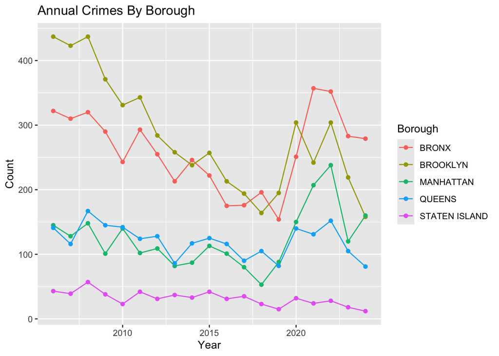

```r
ggplot(date_count, aes(x=year, y=count)) +
  geom_line(aes(color = BORO)) +
  geom_point(aes(color= BORO)) +
  labs(title = "Annual Crimes By Borough", y="Count", x = "Year", color="Borough")
```

```r
age_group <- nypd %>%
  group_by(PERP_AGE_GROUP, VIC_AGE_GROUP) %>%
  summarise(count = n())
```

```
## `summarise()` has regrouped the output.
## ℹ Summaries were computed grouped by PERP_AGE_GROUP and VIC_AGE_GROUP.
## ℹ Output is grouped by PERP_AGE_GROUP.
## ℹ Use `summarise(.groups = "drop_last")` to silence this message.
## ℹ Use `summarise(.by = c(PERP_AGE_GROUP, VIC_AGE_GROUP))` for per-operation
##   grouping (`?dplyr::dplyr_by`) instead.
```

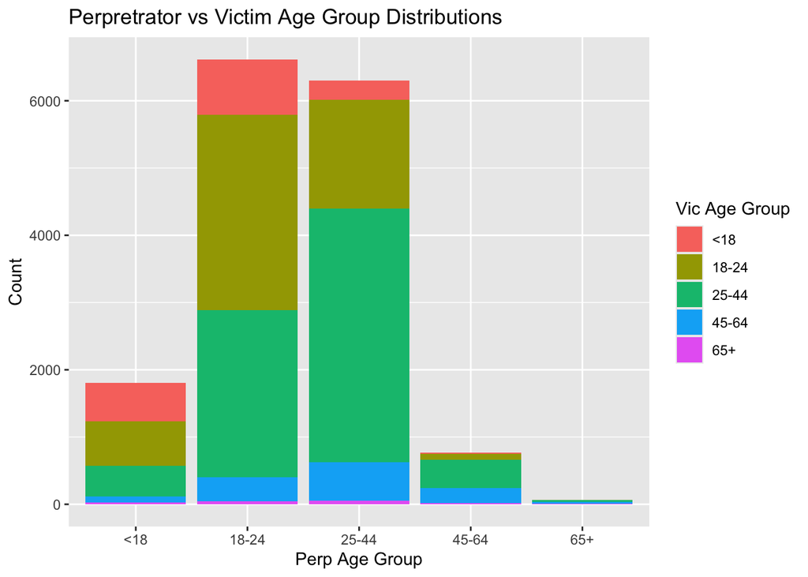

[figure not shown]

```r
ggplot(age_group, aes(x = PERP_AGE_GROUP, y = count, fill = VIC_AGE_GROUP)) +
  geom_col(position = "stack") +
  labs(title = "Perpretrator vs Victim Age Group Distributions", y="Count", x = "Perp Age Group", fill="Vic Age Group")
```

## Model

In terms of a model I wanted to develop, I wanted to predict the probabilities that a victim would fall into a particular age group, given the perpetrator’s age.

```r
#cleaning for model
age_groups <- c("<18", "18-24", "25-44", "45-64", "65+")
nypd$VIC_AGE_GROUP <- factor(nypd$VIC_AGE_GROUP, levels = age_groups)
nypd$PERP_AGE_GROUP <- factor(nypd$PERP_AGE_GROUP, levels = age_groups)

train_idx = sample(seq_len(nrow(nypd)),
                   size = .8*nrow(nypd)
                   )

train <- nypd[train_idx, ]
test <- nypd[-train_idx, ]

lmod <- multinom(
  VIC_AGE_GROUP ~ PERP_AGE_GROUP,
  data = train
)
predict_test <- predict(lmod, newdata = test)

predict_probs <- predict(lmod,
  newdata = test,
  type = "probs"
)

df_prob <- as.data.frame(predict_probs)

df_prob$perp_age <- test$PERP_AGE_GROUP

df_prob <- df_prob[!apply(is.na(df_prob), 1, any), ]

head(df_prob[, c("perp_age", "<18", "18-24", "25-44", "45-64", "65+")])
```

```
##   perp_age        <18     18-24     25-44      45-64         65+
## 1      <18 0.31948542 0.3652129 0.2570963 0.04781181 0.010393607
## 2      <18 0.31948542 0.3652129 0.2570963 0.04781181 0.010393607
## 3    18-24 0.12417735 0.4426261 0.3702599 0.05520936 0.007727281
## 4    25-44 0.04457252 0.2622877 0.5940322 0.09154505 0.007562547
## 5    25-44 0.04457252 0.2622877 0.5940322 0.09154505 0.007562547
## 6    25-44 0.04457252 0.2622877 0.5940322 0.09154505 0.007562547
```

## Conclusion

The NYPD Shooting Incident Data set contains a plethora of information that allows for several avenues of potential investigation and exploration of the data to occur. While I explored two features - location and age, several other features were left unexplored in my analysis and are potentially valuable assets that could lead to further insights. However, one must be extremely cautious to acknowledge bias especially regarding data that has features that could have sociopolitical impact if handled incorrectly. This report could have biases from several sources. Perhaps the filing of the incident was biased in terms of reporting the severity or determination of cause. Or maybe there may be an increased police presence in certain areas, leading to that area having less incidents or other areas having more. These are just potential scenarios that could have introduced bias into this report. In terms of personal bias, I certainly had some feelings towards some of the findings within the age group exploration. I made sure to check my thoughts and remind myself that I should remain impartial and ensure that findings are presented without any connotation. I may have some personal biases regarding other demographic information and it is my duty that I do my duty that when exploring and presenting this data, I understand the contexts, consequences, and purposes of the data so that my analysis is done ethically.